# Examining Differences in Self vs Others’ Perception of Attractiveness

Michelle Hunn, Wenyu Nie, Rory White, Mona Zhu

# 1 Summary

This research delves into the dynamics of self-perceived attractiveness in the context of dating. We explore whether individuals accurately gauge their own appeal compared to external judgments. Analyzing data from speed dating studies, the findings reveal a systematic tendency for individuals to overestimate their attractiveness. While a significant correlation exists between self-ratings and others’ ratings, this research underscores the interplay between self-perception and external judgments in the realm of dating. The implications range from improved self-esteem for those perceiving themselves as more attractive to potential challenges in social interactions. Future research could investigate the influence of contemporary factors like social media on self-perception and exploring the multidimensional aspects of attractiveness.

# 2 Introduction

In the unpredictable dance of dating, where first impressions can set the stage for romantic connections, we want to investigate whether one’s self-perceived attractiveness aligns with the external judgments rendered by potential romantic partners. Research has been conducted to examine how attractiveness impacts dating behavior (Walster et al. 1966). Multiple studies specifically investigated the perception of one’s own attractiveness and the attractiveness of romantic partners. In this context, a “love-is-blind” bias was identified, indicating that individuals tend to perceive their romantic partners as more attractive than they perceive themselves (Swami et al. 2007, 2009). In our research, the focus lies on investigating whether self-perceived attractiveness deviates from objective attractiveness. In this context, we define objective attractiveness as the average ratings from various potential dating partners. The insights gained from this research are intended to help understand how aligned people’s self-perception is with an objective rating in the context of attractiveness.

# 3 Methods

## 3.1 Data

The dataset used in this project were obtained from a series of speed dating studies led by Dr. Ray Fisman and Dr. Sheena Iyengar conducted between 2002 and 2004 at Columbia University (Fisman et al. 2006). Data were collected across 21 different sessions (known as “waves” in the dataset). Data was sourced from OpenML (Vanschoren et al. 2014) and can be found [here](http://www.stat.columbia.edu/~gelman/arm/examples/speed.dating/).

In the experiment, men and women went on a speed dating rotation where they interacted and subsequently rated each other on 6 attributes: attractive, sincere, intelligent, fun, ambitious, and shared interest/hobbies. Critically, they were also asked to report whether they would see this person again or not. In addition to rating the other party, each participant also rated themselves on 5 of the 6 attributes (attractive, sincere, intelligent, fun, ambitious). Specifically, they were asked to rate how they measured up to each attribute, as well as how they thought others perceived them.

An observation or row in the data represents one set of ratings per ratee. For instance, if an individual saw 10 different partners in the session, then that individual would make 10 different ratings, one for each partner they interacted with at the event.

## 3.2 Analysis

We conducted a one-sample t-test in order to examine our core research question of interest (i.e., whether self-perception of attractiveness is accurate). That is, we would take the difference in self- vs other-rated attractiveness and compare it against zero; if our difference score is statistically different from zero, then we would have sufficient evidence to reject the null hypothesis (i.e., that there is no difference between self- vs other-rated attractiveness).

### 3.2.1 Data Pre-Processing

Since observations in the original raw dataset violated assumptions of independence (i.e., each rater made multiple ratings and each ratee received multiple ratings), we decided to first process the data by averaging how each rater rated the attractiveness of each ratee.

Analysis and graphs were produced using the R programming language (Team 2019) as well as the following R packages: tidyverse (Wickham et al. 2019), knitr (Xie 2023). For the full code used to produce this report and analyses, please see: https://github.com/wenyunie/speed_dating_analysis.

# 4 Data Analysis

### 4.0.1 Exploratory Data Analysis

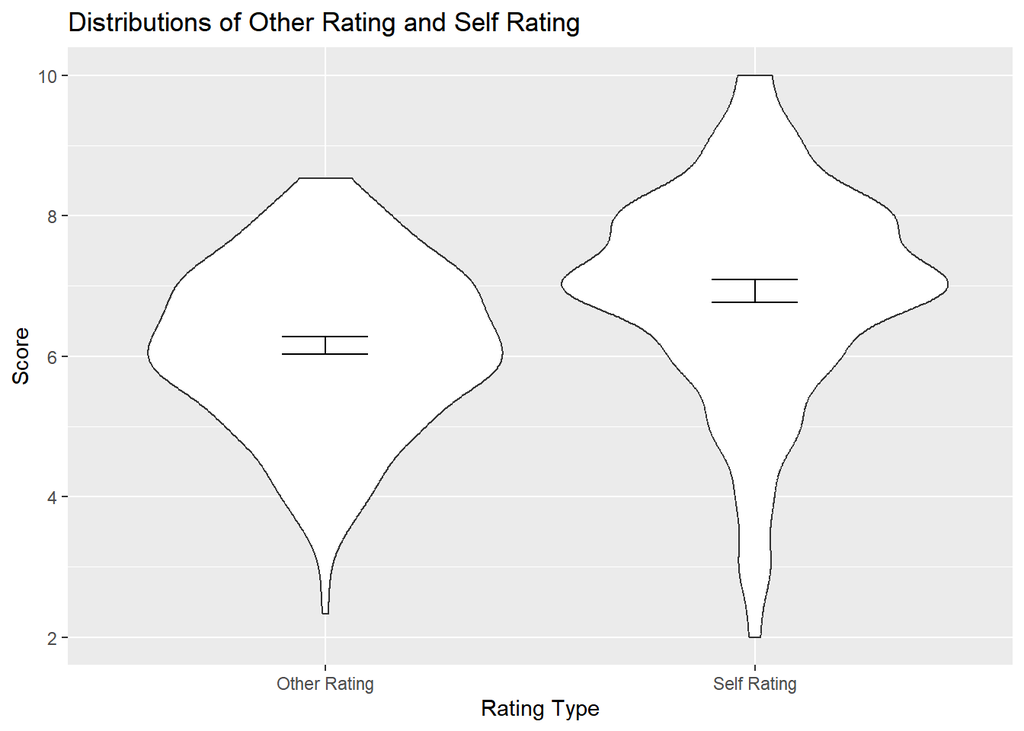

Figure 4.1: Rating of attractiveness by other raters versus self. Error bars denote 95% bootstrap confidence interval.

The non-overalpping 95% bootstrap confidence intervals suggests that there may be a difference in self- vs other-rated attractiveness. We further examine this relationship below.

### 4.0.2 Statistical Analysis

The negative t-value (-8.502) indicates that, on average, individuals tend to overestimate their own attractiveness compared to how others perceive them. The extremely low p-value (7.72^{-16}) supports the rejection of the null hypothesis, further emphasizing the substantial difference in self-perceived attractiveness.

The 95 percent confidence interval for the true mean difference is (-0.968, -0.604) (see Table 4.2). This interval does not include zero, reinforcing the conclusion that individuals exhibit a systematic bias by viewing themselves as more attractive than how others perceive them. This is bias is visually apparent in the distributions shown in Figure 4.1.

Table 4.1: Paired Test Results

| estimate | statistic | p.value | parameter | conf.low | conf.high | method | alternative |
| --- | --- | --- | --- | --- | --- | --- | --- |
| -0.7859287 | -8.502489 | 0 | 313 | -0.9678015 | -0.6040559 | Paired t-test | two.sided |

Table 4.2: Difference Test Results

| estimate | statistic | p.value | parameter | conf.low | conf.high | method | alternative |
| --- | --- | --- | --- | --- | --- | --- | --- |
| -0.7859287 | -8.502489 | 0 | 313 | -0.9678015 | -0.6040559 | One Sample t-test | two.sided |

An additional test was performed to examine if the difference is a systematic and constant overrating of one’s own attributes, or if the self-rating is also not accurate in the sense that it is not correlated to others’ perception at all (see Table 4.3) and the correlation was visualized in Figure 4.2.

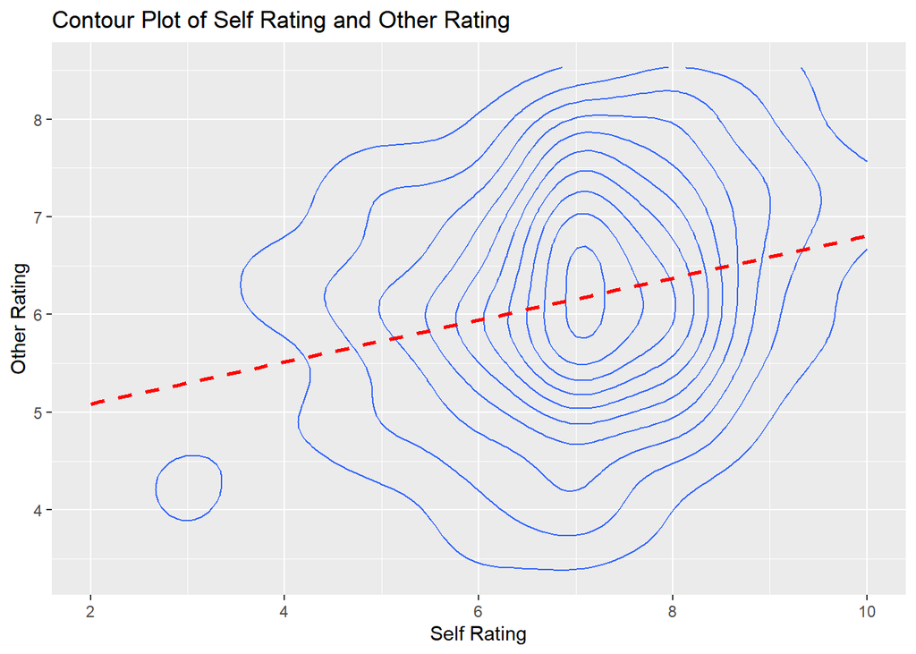

Figure 4.2: Contour plot of the relationship between self vs others’ rating of attractiveness. The red dashed line (r = 0.2745) indicates a weak significant correlation between these two variables.

The observed correlation is 0.275, with a 95 percent confidence interval between 0.186 and 1. The p-value of 3.89^{-7} is smaller than the commonly used significance level of 0.05. Therefore, we have sufficient evidence to reject the null hypothesis in favor of the alternative hypothesis. The null hypothesis in this case is that the true correlation between self rating and others’ perception is equal to 0. The 95 percent confidence interval does not include 0, further supporting the hypothesis of a significant correlation.

Table 4.3: Pearson Correlation Test Results

| estimate | statistic | p.value | parameter | conf.low | conf.high | method | alternative |
| --- | --- | --- | --- | --- | --- | --- | --- |
| 0.2745402 | 5.043125 | 4e-07 | 312 | 0.1862952 | 1 | Pearson’s product-moment correlation | greater |

In summary, the numerical results strongly support the conclusion that individuals have a tendency to be overly confident in their self-perceived attractiveness. The statistical evidence indicates a significant pattern of overestimation. However, further analysis shows that self-ratings and others’ ratings of attractiveness have at least a small correlation. These findings shed a light on the dynamics of self-perception in social contexts.

# 5 Discussion

## 5.1 Interpretation

These findings echo existing research on self-perceived physical attractiveness. A meta-analysis of 21 studies found that self-perceived physical attractiveness correlates weakly (r=0.24) with physical attractiveness judged by others (Feingold 1992). This is consistent with the ‘above-average-effect’ in human psychology, where individuals overestimate personal traits like attractiveness and intelligence compared to objective measures (Logg, Haran, and Moore 2018).

This strong contextual backing gives greater confidence in the generalizability of our findings, despite the applicability of our statistical findings being limited to university students in a speed dating environment. Our 95% confidence interval of between 0.60 and 0.97 points out of 10 represents an overestimation magnitude of 6.0% to 9.7%. This is consistent with the magnitude observed in multiple studies of university students (Greitemeyer 2020). In general, perception of physical attractiveness is deeply influenced by cultural norms and life experiences - there is no truly objective measure. Here, the opinions of 6 to 22 different raters were mean-averaged to create a consensus score. To increase the robustness of the findings, additional analyses might include applying weights to participant diversity and exploring alternative consensus metrics, such as the median score.

## 5.2 Implications

Overestimating one’s attractiveness has complex psychological implications. People with a higher self-perception of attractiveness tend to have better self-esteem, which positively influences their mental health and overall happiness (Bale and Archer 2013). Yet, an inflated sense of attractiveness may cause misinterpretations of social cues and foster unrealistic relationship expectations, potentially causing social challenges. An interesting avenue of future research could be assessing interventions aimed at aligning self-perception with a more realistic view - though this could have negative mental health consequences.

## 5.3 Future work

Considering the 2004 data collection, there’s significant scope for follow-up research to reflect current influences. In particular, the invention of social media has created an environment where individuals are exposed to heavily edited and idealized images, leading to a potential “Instagram effect” on self-perception norms (Faelens et al. 2021). The existing data set also holds a wealth of unexplored dimensions. By expanding our self-perception analysis to include sincerity and intelligence, we could explore whether the trend of overestimating one’s physical attractiveness correlates with similar biases in these other domains. Incorporating the existing data on personality, occupation, and age could enable a comprehensive multivariate analysis. Such an approach would provide deeper insights into how they collectively shape and influence the discrepancies in self-perception.

# References

Bale, Christopher, and John Archer. 2013. “Self-Perceived Attractiveness, Romantic Desirability and Self-Esteem: A Mating Sociometer Perspective.” *Evolutionary Psychology* 11 (1): 147470491301100107. https://doi.org/10.1177/147470491301100107.

Faelens, Lien, Kristof Hoorelbeke, Ruben Cambier, Jill van Put, Eowyn Van de Putte, Rudi De Raedt, and Ernst HW Koster. 2021. “The Relationship Between Instagram Use and Indicators of Mental Health: A Systematic Review.” *Computers in Human Behavior Reports* 4: 100121. https://doi.org/10.1016/j.chbr.2021.100121.

Feingold, Alan. 1992. “Good-Looking People Are Not What We Think.” *Psychological Bulletin* 111 (2): 304. https://doi.org/10.1037/0033-2909.111.2.304.

Fisman, Raymond, Sheena S Iyengar, Emir Kamenica, and Itamar Simonson. 2006. “Gender Differences in Mate Selection: Evidence from a Speed Dating Experiment.” *The Quarterly Journal of Economics* 121 (2): 673–97. https://doi.org/10.1162/qjec.2006.121.2.673.

Greitemeyer, Tobias. 2020. “Unattractive People Are Unaware of Their (Un)attractiveness.” *Scandinavian Journal of Psychology* 61 (4): 471–83. https://doi.org/10.1111/sjop.12631.

Logg, Jennifer M, Uriel Haran, and Don A Moore. 2018. “Is Overconfidence a Motivated Bias? Experimental Evidence.” *Journal of Experimental Psychology: General* 147 (10): 1445. https://doi.org/10.1037/xge0000500.

Swami, Viren, Adrian Furnham, Chrissa Georgiades, and Lily Pang. 2007. “Evaluating Self and Partner Physical Attractiveness.” *Body Image* 4 (1): 97–101. https://doi.org/10.1016/j.bodyim.2006.10.003.

Swami, Viren, Stefan Stieger, Tanja Haubner, Martin Voracek, and Adrian Furnham. 2009. “Evaluating the Physical Attractiveness of Oneself and One’s Romantic Partner: Individual and Relationship Correlates of the Love-Is-Blind Bias.” *Journal of Individual Differences* 30 (1): 35–43. https://doi.org/10.1027/1614-0001.30.1.35.

Team, R Core. 2019. *R: A Language and Environment for Statistical Computing*. Vienna, Austria: R Foundation for Statistical Computing. https://www.R-project.org.

Vanschoren, Joaquin, Jan N Van Rijn, Bernd Bischl, and Luis Torgo. 2014. “OpenML: Networked Science in Machine Learning.” *ACM SIGKDD Explorations Newsletter* 15 (2): 49–60. https://doi.org/10.1145/2641190.2641198.

Walster, Elaine, Vera Aronson, Darcy Abrahams, and Leon Rottman. 1966. “Importance of Physical Attractiveness in Dating Behavior.” *Journal of Personality and Social Psychology* 4 (5): 508. https://doi.org/10.1037/h0021188.

Wickham, Hadley, Mara Averick, Jennifer Bryan, Winston Chang, Lucy D’Agostino McGowan, Romain François, Garrett Grolemund, et al. 2019. “Welcome to the Tidyverse.” *Journal of Open Source Software* 4 (43): 1686. https://doi.org/10.21105/joss.01686.

Xie, Yihui. 2023. *Knitr: A General-Purpose Package for Dynamic Report Generation in r*. https://yihui.org/knitr/.